# homework

Zhao js

2021-12-17

## Question

Exercises 3.4, 3.11, and 3.20 (pages 94-96, Statistical Computating with R).

## Answer

### 3.4: Using inverse transform method.

Because I can’t find a command distribution which has density function $g(x)$ such that there is a constant $c$ satisfy $f(x) \le cg(x)$, I don’t use acceptance-rejection method.

I use inverse transform method to solve the problem.

$$F(x) = P(X \le x) = \int_{-\infty}^x f(t)dt = \int_0^x \frac{t}{\sigma^2} e^{-t^2/(2\sigma^2)} dt
= \int_0^x -e^{-t^2/(2\sigma^2)} d(-t^2/(2\sigma^2))=(-e^t)|_0^{-x^2/(2\sigma^2)}=1-e^{-x^2/(2\sigma^2)}$$
The inverse function is $F^{-1}(x) = \left( -2\sigma^2 \log(1-x) \right)^{\frac{1}{2}}$.

The algorithm generating random samples from a Rayleigh($\sigma$) distribution is as follows:

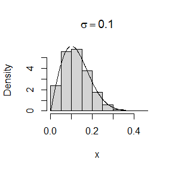

```r
## sigma = 0.1
n <- 10000
Sigma <-0.1
u <- runif(n)
x <- sqrt(-2 * Sigma^2 * log(1-u))
hist(x, prob =TRUE, main = expression(sigma==0.1) ) # generated sample mode
y <- seq(0,0.5, .001)
lines(y,y/(Sigma^2)*exp(-y^2/(2*Sigma^2))) #the theoretical mode
```

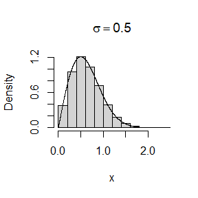

```r
## sigma = 0.5
n <- 10000
Sigma <-0.5
u <- runif(n)
x <- sqrt(-2 * Sigma^2 * log(1-u))
hist(x, prob =TRUE, main = expression(sigma==0.5) ) # generated sample mode
y <- seq(0,3, .001)
lines(y,y/(Sigma^2)*exp(-y^2/(2*Sigma^2))) #the theoretical mode
```

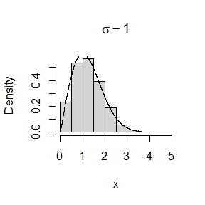

```r
## sigma = 1
n <- 10000
Sigma <-1
u <- runif(n)
x <- sqrt(-2 * Sigma^2 * log(1-u))
hist(x, prob =TRUE, main = expression(sigma==1) ) # generated sample mode
y <- seq(0,4, .001)
lines(y,y/(Sigma^2)*exp(-y^2/(2*Sigma^2))) #the theoretical mode
```

As can be seen from the above three graphs, the mode of the generated samples is close to the theoretical mode.

### 3.11: Generate a random sample of size 1000 from a normal location mixture.

The code to generate a random sample of size 1000 from $N(0,1)$ and $N(3,1)$ distribution with mixing probabilities $p_1$ and $p_2 = 1 − p_1$ is as follows.

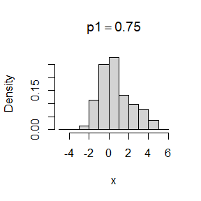

```r
## p1=0.75
n <-1000
x1 <- rnorm(n)
x2 <- rnorm(n, 3, 1)
p1 = rbinom(n,1,0.75)
x = p1*x1 + (1-p1)*x2
hist(x,prob =TRUE, main = expression(p1==0.75))
```

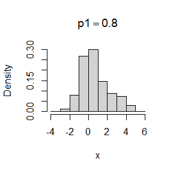

```r
## p1=0.8
n <-1000
x1 <- rnorm(n)
x2 <- rnorm(n, 3, 1)
p1 = rbinom(n,1,0.8)
x = p1*x1 + (1-p1)*x2
hist(x,prob =TRUE, main = expression(p1==0.8))
```

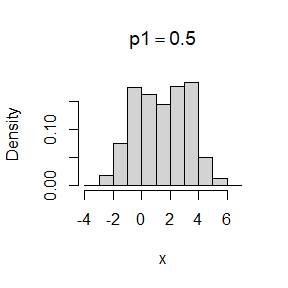

```r
## p1=0.5
n <-1000
x1 <- rnorm(n)
x2 <- rnorm(n, 3, 1)
p1 = rbinom(n,1,0.5)
x = p1*x1 + (1-p1)*x2
hist(x,prob =TRUE, main = expression(p1==0.5))
```

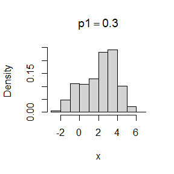

```r
## p1=0.3
n <-1000
x1 <- rnorm(n)
x2 <- rnorm(n, 3, 1)
p1 = rbinom(n,1,0.3)
x = p1*x1 + (1-p1)*x2
hist(x,prob =TRUE, main = expression(p1==0.3))
```

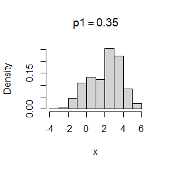

```r
## p1=0.35
n <-1000
x1 <- rnorm(n)
x2 <- rnorm(n, 3, 1)
p1 = rbinom(n,1,0.35)
x = p1*x1 + (1-p1)*x2
hist(x,prob =TRUE, main = expression(p1==0.35))
```

From above figures with various $p_1$, I find that when $p_1>0.75$ or $p_1<0.35$ it doesn’t produce bimodal mixtures. Therefore I conjecture when $0.35 \le p_1 \le 0.75$ it produce bimodal mixtures.

### 3.20: Write a program to simulate a compound Poisson$(\lambda)$ –Gamma process (Y has a Gamma distribution) Estimate the mean and the variance of X(10) for several choices of the parameters and compare with the theoretical values. Hint: Show that $E[X(t)] = λtE[Y_1]$ and $Var(X(t)) = λtE[Y_1^2 ]$.

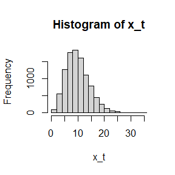

```r
n <- 1e4
t <-10;r <- 1; beta <-1 ; lambda <-1 ;
N_t <- rpois(n, lambda*t)
x_t <- rep(0,n)
for (i in 1:n) {
  y <- rgamma(N_t[i], r, beta)
  x_t[i] <- sum(y)
}
hist(x_t)
```

```r
cat("mean:",mean(x_t))
```

```
## mean: 9.938876
```

```r
cat("variance:",var(x_t))
```

```
## variance: 19.9803
```

```r
#print(mean(x_t))
#print(var(x_t))
```

## Question

Exercises 3.4, 3.11, and 3.20 (pages 94-96, Statistical Computating with R).

## Answer

### 3.4: Using inverse transform method.

Because I can’t find a command distribution which has density function $g(x)$ such that there is a constant $c$ satisfy $f(x) \le cg(x)$, I don’t use acceptance-rejection method.

I use inverse transform method to solve the problem.

$$F(x) = P(X \le x) = \int_{-\infty}^x f(t)dt = \int_0^x \frac{t}{\sigma^2} e^{-t^2/(2\sigma^2)} dt
= \int_0^x -e^{-t^2/(2\sigma^2)} d(-t^2/(2\sigma^2))=(-e^t)|_0^{-x^2/(2\sigma^2)}=1-e^{-x^2/(2\sigma^2)}$$
The inverse function is $F^{-1}(x) = \left( -2\sigma^2 \log(1-x) \right)^{\frac{1}{2}}$.

The algorithm generating random samples from a Rayleigh($\sigma$) distribution is as follows:

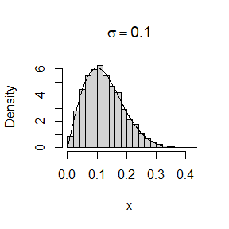

```r
## sigma = 0.1
n <- 10000
Sigma <-0.1
u <- runif(n)
x <- sqrt(-2 * Sigma^2 * log(1-u))
hist(x, prob =TRUE, main = expression(sigma==0.1) ) # generated sample mode
y <- seq(0,0.5, .001)
lines(y,y/(Sigma^2)*exp(-y^2/(2*Sigma^2))) #the theoretical mode
```

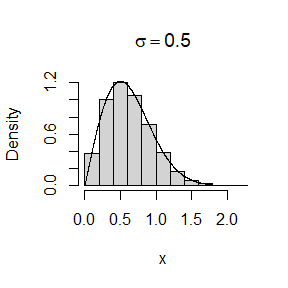

```r
## sigma = 0.5
n <- 10000
Sigma <-0.5
u <- runif(n)
x <- sqrt(-2 * Sigma^2 * log(1-u))
hist(x, prob =TRUE, main = expression(sigma==0.5) ) # generated sample mode
y <- seq(0,3, .001)
lines(y,y/(Sigma^2)*exp(-y^2/(2*Sigma^2))) #the theoretical mode
```

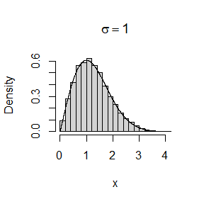

```r
## sigma = 1
n <- 10000
Sigma <-1
u <- runif(n)
x <- sqrt(-2 * Sigma^2 * log(1-u))
hist(x, prob =TRUE, main = expression(sigma==1) ) # generated sample mode
y <- seq(0,4, .001)
lines(y,y/(Sigma^2)*exp(-y^2/(2*Sigma^2))) #the theoretical mode
```

As can be seen from the above three graphs, the mode of the generated samples is close to the theoretical mode.

### 3.11: Generate a random sample of size 1000 from a normal location mixture.

The code to generate a random sample of size 1000 from $N(0,1)$ and $N(3,1)$ distribution with mixing probabilities $p_1$ and $p_2 = 1 − p_1$ is as follows.

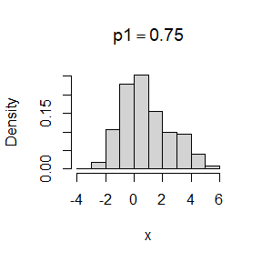

```r
## p1=0.75
n <-1000
x1 <- rnorm(n)
x2 <- rnorm(n, 3, 1)
p1 = sample(0:1, size = n, replace = TRUE, prob = c(.25, .75))
x = p1*x1 + (1-p1)*x2
hist(x,prob =TRUE, main = expression(p1==0.75))
```

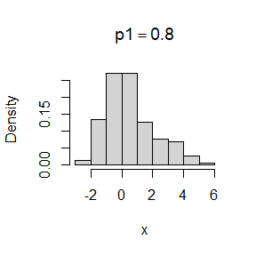

```r
## p1=0.8
n <-1000
x1 <- rnorm(n)
x2 <- rnorm(n, 3, 1)
p1 = rbinom(n,1,0.8)
x = p1*x1 + (1-p1)*x2
hist(x,prob =TRUE, main = expression(p1==0.8))
```

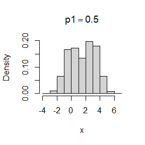

```r
## p1=0.5
n <-1000
x1 <- rnorm(n)
x2 <- rnorm(n, 3, 1)
p1 = rbinom(n,1,0.5)
x = p1*x1 + (1-p1)*x2
hist(x,prob =TRUE, main = expression(p1==0.5))
```

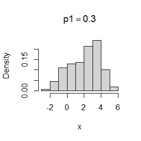

```r
## p1=0.3
n <-1000
x1 <- rnorm(n)
x2 <- rnorm(n, 3, 1)
p1 = rbinom(n,1,0.3)
x = p1*x1 + (1-p1)*x2
hist(x,prob =TRUE, main = expression(p1==0.3))
```

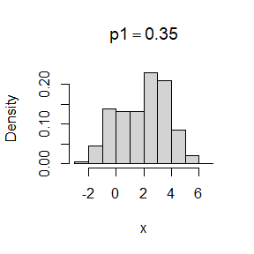

```r
## p1=0.35
n <-1000
x1 <- rnorm(n)
x2 <- rnorm(n, 3, 1)
p1 = rbinom(n,1,0.35)
x = p1*x1 + (1-p1)*x2
hist(x,prob =TRUE, main = expression(p1==0.35))
```

From above figures with various $p_1$, I find that when $p_1>0.75$ or $p_1<0.35$ it doesn’t produce bimodal mixtures. Therefore I conjecture when $0.35 \le p_1 \le 0.75$ it produce bimodal mixtures.

### 3.20: Write a program to simulate a compound Poisson$(\lambda)$ –Gamma process (Y has a Gamma distribution) Estimate the mean and the variance of X(10) for several choices of the parameters and compare with the theoretical values. Hint: Show that $E[X(t)] = λtE[Y_1]$ and $Var(X(t)) = λtE[Y_1^2 ]$.

First, I prove that $E[X(t)] = \lambda t E[Y_1]$ and $Var(X(t)) = \lambda t E[Y_1^2]$

$proof:$

$$\begin{align}
E[X(t)]= & E[\Sigma_{i=1}^{N(t)}Y_i] = E[N(t)Y_1] = E\{E[N(t)Y_1|N(t)]\} =E\{N(t)E[Y_1]\}
= E[N(t)]E[Y_1]=\lambda tE[Y_1]\\
Var(X(t)) = & E[X^2(t)]-E^2[X(t)] = E\{E[X^2(t)|N(t)]\}-E^2[X(t)]=E\{Var(X(t)|N(t))+E^2[X(t)|N(t)]\}-E^2[X(t)]\\
= & E\{Var(\Sigma_{i=1}^{N(t)}Y_1|N(t))+E^2[\Sigma_{i=1}^{N(t)}Y_1|N(t)]\}-E^2[X(t)]
= E\{N(t)Var(Y_1)\}+N(t)^2 E^2[Y_1] \}-E^2[X(t)]\\
= & E[N(t)]Var(Y_1)+E[N(t)^2]E^2[Y_1]-E^2[N(t)]E^2[Y_1]=E[N(t)]Var(Y_1)+Var(N(t))E^2[Y_1]\\
= & \lambda t Var(Y_1)+\lambda t E^2[Y_1]=\lambda t E[Y_1^2]
\end{align}$$

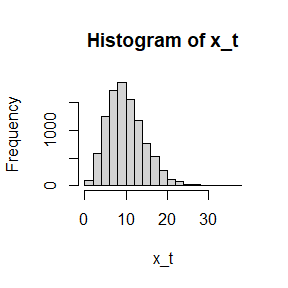

```r
## alpha = 1, beta = 1, lambda = 1
n <- 1e4
t <-10;alpha <- 1; beta <-1 ; lambda <-1 ;
N_t <- rpois(n, lambda*t)
x_t <- rep(0,n)
for (i in 1:n) {
  y <- rgamma(N_t[i], alpha, beta)
  x_t[i] <- sum(y)
}
hist(x_t)
```

```r
cat("mean:",mean(x_t))
```

```
## mean: 10.00755
```

```r
cat("variance:",var(x_t))
```

```
## variance: 20.39918
```

The theoretical values of $E[X(t)]$ and $Var(X(t))$ is $E[X(t)]=\lambda t E[Y_1]=\lambda t \alpha/\beta=$ 10 , $Var(X(t))=\lambda t E[Y_1^2]=\lambda t (\alpha^2+\alpha)/\beta^2=$ 20.

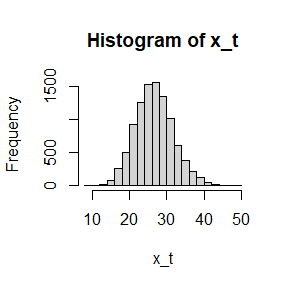

```r
## alpha = 2, beta = 3, lambda = 4
n <- 1e4
t <-10;alpha <- 2; beta <-3 ; lambda <-4 ;
N_t <- rpois(n, lambda*t)
x_t <- rep(0,n)
for (i in 1:n) {
  y <- rgamma(N_t[i], alpha, beta)
  x_t[i] <- sum(y)
}
hist(x_t)
```

```r
cat("mean:",mean(x_t))
```

```
## mean: 26.65885
```

```r
cat("variance:",var(x_t))
```

```
## variance: 26.05153
```

The theoretical values of $E[X(t)]$ and $Var(X(t))$ is $E[X(t)]=\lambda t E[Y_1]=\lambda t \alpha/\beta=$ 26.6666667 , $Var(X(t))=\lambda t E[Y_1^2]=\lambda t (\alpha^2+\alpha)/\beta^2=$ 26.6666667.

We can see that the estimate of the mean and the variance of X(10) for several choices of the parameters is close to the theoretical values.

## Question

Exercises 5.4, 5.9, 5.13, and 5.14 (pages 149-151, Statistical Computating with R).

### 5.4: Write a function to compute a Monte Carlo estimate of the **Beta(3, 3)** cdf, and use the function to estimate F(x) for x = 0.1, 0.2, . . ., 0.9. Compare the estimates with the values returned by the pbeta function in R.

```r
MC_Beta <- function(x, alpha=3, beta=3, n=1000) {
  u <- runif(n)
  thetahat <- numeric(length(x))
  for (i in 1:length(x)){
  thetahat[i] <- mean(x[i]* (x[i]*u)^(alpha-1)* (1-u*x[i])^(beta-1) /beta(alpha, beta))
  }
  thetahat
}
```

Using the function estimate $F(x)$ for $x= 0.1,0.2,\ldots ,0.9$. And compare with **pbeta** function.

```r
x = seq(0.1, 0.9, 0.1)
estimate <- round(MC_Beta(x),5)
theoretical <- pbeta(x, 3,3)
data.frame(estimate, theoretical,row.names = x)
```

```
##     estimate theoretical
## 0.1  0.00871     0.00856
## 0.2  0.05893     0.05792
## 0.3  0.16599     0.16308
## 0.4  0.32326     0.31744
## 0.5  0.50943     0.50000
## 0.6  0.69580     0.68256
## 0.7  0.85353     0.83692
## 0.8  0.96097     0.94208
## 0.9  1.01086     0.99144
```

[figure not shown]

```r
plot(x, estimate,'l',col =1,)
lines(x, theoretical, col =2,)
gs = c(expression((X1+X2)/2), expression((X+X^{prime})/2) )
legend("topleft", legend = gs,
            lwd = 2, inset = 0.02,col=1:2)
```

We can find the MC estimate value is close to the value generate from **pbeta** function in R.

### 5.9: The Rayleigh density is

$$f(x) = \frac{x}{\sigma^2} e^{-x^2/(2 \sigma^2)}, x\ge 0, \sigma>0$$
Implement a function to generate samples from a Rayleigh($\sigma$) distribution, using antithetic variables. What is the percent reduction in variance of $\frac{X+X'}{2}$ compared with $\frac{X_1+X_2}{2}$ for independent $X_1, X_2$ ?

I use inverse transform method to solve the problem.

$$F(x) = \int_0^x \frac{t}{\sigma^2} e^{-t^2/(2\sigma^2)}=1-e^{-x^2/(2\sigma^2)}$$

$$F^{-1}(u) = \left( -2\sigma^2 \log(1-u) \right)^{\frac{1}{2}},0<u<1$$
.

$$F^{-1}(1-u)= \left( -2\sigma^2 \log(u) \right)^{\frac{1}{2}},0<u<1$$
The function to generate samples from a Rayleigh(σ) distribution, using antithetic variables, as follows:

```r
sampling <- function(n=1, sigma = 1,antithetic = TRUE){
  U = runif(n)
  if (antithetic) X = sqrt(-2*log(U[1:(n)]))*sigma +  sqrt(-2*log(1-U[1:(n)]))*sigma else X = sqrt(-2*log(U))*sigma + sqrt(-2*log(U))*sigma
  X/2
}
```

```r
m <- 1000
MC1 <- sampling(n = 1000, antithetic = FALSE)
MC2 <- sampling(n = 1000)
print((var(MC1)-var(MC2))/var(MC1))
```

```
## [1] 0.9723522
```

We can find the the percent reduction in variance achieve 97%.

### 5.13: Find two importance functions $f_1$ and $f_2$ that are supported on $(1,\infty)$ and are ‘close’ to

$$g(x)=\frac{x^2}{\sqrt{2\pi}}e^{-x^2/2}, x>1.$$
Which of your two importance functions should produce the smaller variance in estimating
$$\int_1^{\infty}\frac{x^2}{\sqrt{2\pi}}e^{-x^2/2}dx$$
by importance sampling? Explain.

The importance function that are supported on $(1, \infty)$ are Exponential Distribution and Normal Distribution.

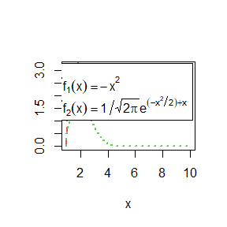

```r
x <- seq(1, 10, .01)
g <- x^2/sqrt(2*pi)*exp(-x^2/2) * (x > 1)
f1 <- 1/sqrt(2*pi) *exp(-x^2/2)
f2 <-  exp(-x)
gs <- c(expression(g/f[1](x)==-x^2),
            expression(g/f[2](x)==1/sqrt(2*pi)*e^{(-x^2/2)+x}))
plot(x, g/f1, type = "l", ylab = "",
       ylim = c(0,3.2), lwd = 2, lty = 2,col = 2)
lines(x, g/f2, lty = 3, lwd=2,col=3)
legend("topright", legend = gs,
           lty = 2:3, lwd = 2, inset = 0.02,col=2:3)
```

The exponential distribution has the smaller variance. The reason is that $g/f_2$ is closer to constant which means $f_2(x)$ is closer to $g(x)$.

### 5.14 Obtain a Monte Carlo estimate of

$$\int_1^{\infty} \frac{x^2}{\sqrt{2 \pi}}e^{-x^2/2}dx$$
by importance sampling.

```r
m <- 10000
est <- sd <- numeric(2)
g <- function(x) {
  x^2/sqrt(2*pi)*exp(-x^2/2) * (x > 1)
}
x <- rnorm(m) #using normal distribution f1 =1/sqrt(2*pi) *exp(-x^2/2)
fg <- x^2 * (x>1) # g/f = x^2 (x>1)
est[1] <- mean(fg)
sd[1] <- sd(fg)/sqrt(m)
x <- rexp(m, 1) #using exponential distribution f2 = e^(-x)
fg <- g(x) / exp(-x)
est[2] <- mean(fg)
sd[2] <- sd(fg)/sqrt(m)
res <- rbind(est=round(est,5), sd=round(sd,5))
colnames(res) <- paste0('f',1:2)
knitr::kable(res,align='c')
```

|  | f1 | f2 |
| --- | --- | --- |
| est | 0.38886 | 0.39612 |
| sd | 0.01117 | 0.00585 |

## Question

Exercises 6.5 and 6.A (page 180-181, Statistical Computating with R). If we obtain the powers for two methods under a particular

simulation setting with 10,000 experiments: say, 0.651 for one method and 0.676 for another method. We want to know if the powers are different at 0.05 level.

- I What is the corresponding hypothesis test problem?
- I What test should we use? Z-test, two-sample t-test, paired-t test or McNemar test? Why?
- I Please provide the least necessary information for hypothesis testing.

### 6.5: Suppose a 95% symmetric t-interval is applied to estimate a mean, but the

sample data are non-normal. Then the probability that the confidence interval covers the mean is not necessarily equal to 0.95. Use a Monte Carlo experiment to estimate the coverage probability of the t-interval for random samples of χ2(2) data with sample size n = 20. Compare your t-interval results with the simulation results in Example 6.4. (The t-interval should be more robust to departures from normality than the interval for variance.)

```r
m<-1e4
n <-20
alpha <- .05
L <- U <- numeric(m)
for(i in 1:m){
  x <- rchisq(n, df = 2)
  L[i] <- mean(x)-(sd(x)/sqrt(n-1)) * qt(1-alpha/2,df = n-1)
  U[i] <- mean(x)+(sd(x)/sqrt(n-1)) * qt(1-alpha/2,df = n-1)
}
mean(L<2 & U>2)
```

```
## [1] 0.9254
```

Compare the t-interval results with the simulation results in Example 6.4,we find that this coverage probability of the t-interval is smaller.

### 6.A: Use Monte Carlo simulation to investigate whether the empirical Type I error rate of the t-test is approximately equal to the nominal significance level $\alpha$, when the sampled population is non-normal. The t-test is robust to mild departures from normality. Discuss the simulation results for the cases where the sampled population is (i) χ2(1), (ii) Uniform(0,2), and (iii) Exponential(rate=1). In each case, test H0 : µ = µ0 vs H0 : µ ̸= µ0, where µ0 is the

mean of χ2(1), Uniform(0,2), and Exponential(1), respectively.

1. The mean values of chisq(1),Uniform(0,2) and Exponential(1) are all 1.

```r
mu0 <- 1 # null hypothesis!
alpha <- .05
m <- 1e4; n <- 20; set.seed(123)
p1 <- p2 <- p3 <- numeric(m)
for (i in 1:m){
  x1 <- rchisq(n,df =1)
  x2 <- runif(n,0,2)
  x3 <- rexp(n,1)
  ttest1 <-  t.test(x1, alternative = "greater", mu = mu0)
  ttest2 <-  t.test(x2, alternative = "greater", mu = mu0)
  ttest3 <-  t.test(x3, alternative = "greater", mu = mu0)
  p1[i] <- ttest1$p.value
  p2[i] <- ttest2$p.value
  p3[i] <- ttest3$p.value
}

p.hat <- c(mean(p1 < alpha), mean(p2 < alpha), mean(p3 < alpha))

se.hat <- sqrt(p.hat*(1-p.hat)/m)

data.frame(p.hat, se.hat,row.names = c("(i)χ2(1)", "(ii)Uniform(0,2)", "(iii)Exponential(1)"))
```

```
##                      p.hat      se.hat
## (i)χ2(1)            0.0133 0.001145561
## (ii)Uniform(0,2)    0.0486 0.002150303
## (iii)Exponential(1) 0.0189 0.001361719
```

The observed Type I error rate of chisq2(1), Uniform(0,2), and Exponential(1) are 0.0133, 0.0486, 0.0189 and the standard error of the estimate are 0.001145561, 0.002150303, 0.001361719. The estimates of Type I error probability are vary ,but should be close to the nominal rate $\alpha$= 0.05. Howere ,we find that only the Type I error probability of uniform(0,2) is close to 0.05. When n is large enough , the Type I error of chisq2(1) and Exponential(1) will close to 0.05.

- I What is the corresponding hypothesis test problem?
- I What test should we use? Z-test, two-sample t-test, paired-t test or McNemar test? Why?
- I Please provide the least necessary information for hypothesis testing.

(1)if we make powers for two methods under a particular simulation is p1 and p2,the corresponding hypothesis test problem is
$$H_0 :p_1=p_2 \quad vs \quad H_1:p_1 \not=p_2$$

(2)In my opinion,we can use Z-test, paired-t test or McNemar test, in Z-test we can make $Z_i = Y_i − X_i$,paired-t test and McNemar test are used for the analysis of paired count data, and they can analyze whether the results before and after the experiment are different.However,two-sample t-test requires the samples to be independent. Obviously, the samples in the question are the same set of samples, which cannot be independent of each other,thus we shouldn’t choose it.

(3)To test my hypothesis, we need to know Sample mean,Sample var,Sample size etc, .

## Question

Exercises 6.C (pages 182, Statistical Computating with R).

### Answer

6.C Repeat Examples 6.8 and 6.10 for Mardia’s multivariate skewness test. Mardia [187] proposed tests of multivariate normality based on multivariate generalizations of skewness and kurtosis. If $X$ and $Y$ are iid, the multivariate population skewness $\beta_{1,d}$ is defined by Mardia as
$$\beta_{1,d} = E[(X-\mu)^T \Sigma^{-1}(Y-\mu)]^3.$$
Under normality, $\beta_{1,d}=0$. The multivariate skewwness statistic is
$$b_{1,d}= \frac{1}{n^2} \sum_{i,j=1}^{n}((X_i-\bar{X})^T \hat{\Sigma}^{-1} (X_j-\bar{X}))^3,$$
where $\hat{\Sigma}$ is the maximum likelihood estimator of covariance. Large values of $b_{1,d}$ are significant. The asymptotic distribution of $nb_{1,d}/6$ is chisquqred with $d(d+1)(d+2)/6$ degrees of freedom.

Example 6.8

The hypotheses are
$$H_0 : \sqrt{\beta_{1,d}} =0; \quad H_1 : \sqrt{\beta_{1,d}} \ne 0,$$
where the sampling distribution of the skewness statistic is derived under the assumption of normality. Assess the Type I error rate for a skewness test of normality at $\alpha$ = 0.05 based on the asymptotic distribution of $\sqrt{b_1}$ for sample sizes n = 10, 20, 30, 50, 100, and 500.

```r
library(MASS) # genrate multi-normal distribution
n <- c(10, 20, 30, 50, 100, 500) # sample size
d <- 2 # dimension
cv_U <- qchisq(0.975, d*(d+1)*(d+2)/6)
cv_L <- qchisq(0.025, d*(d+1)*(d+2)/6)
sigma <- (matrix(c(5,0,0,1),2,2))
mu<-c(1,4)

mul_sk <- function(x){
  n <- nrow(x)
  x_bar <- matrix(c(mean(x[,1]),mean(x[,2])),n,2, byrow=TRUE)
  x_ <- x-x_bar
  sigma_hat <- var(x)*(n-1)/n # MLE
  b <- mean((x_ %*% solve(sigma_hat) %*% t(x_))^3)
  return(n*b/6)
}

p.reject <- numeric(length(n)) #to store sim. results
m <- 1000 #num. repl. each sim.

for (i in 1:length(n)) {
  sktests <- numeric(m) #test decisions
  for (j in 1:m) {
    x<-mvrnorm(n[i],mu,sigma)
    sktests[j] <- as.integer((mul_sk(x) <=cv_L) |( mul_sk(x)>= cv_U))
  }
  p.reject[i] <- mean(sktests) #proportion rejected
}

print(p.reject)
```

```
## [1] 0.050 0.055 0.057 0.044 0.054 0.050
```

Example 6.10

For this experiment, the significance level is $\alpha$ = 0.1 and the sample size is n = 30. The skewness statistic mul_sk is implemented in Example 6.8.

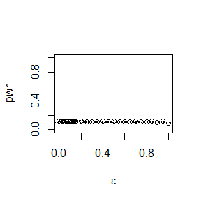

```r
alpha <- .1
n <- 30
m <- 2500
sigma1 <- matrix(c(5,0,0,1),2,2)
sigma2 <- matrix(c(8,0,0,1),2,2)
mu<-c(0,0)
epsilon <- c(seq(0, .15, .01), seq(.15, 1, .05))
N <- length(epsilon)
pwr <- numeric(N) #critical value for the skewness test
cv_U <- qchisq(1-alpha/2, d*(d+1)*(d+2)/6)
cv_L <- qchisq(alpha/2, d*(d+1)*(d+2)/6)
for (j in 1:N) { #for each epsilon
  e <- epsilon[j]
  sktests <- numeric(m)
  for (i in 1:m) {
  #for each replicate
    a <- sum(sample(c(0,1), replace = TRUE,size = n, prob = c(1-e, e)))
    if(a==0){x<-mvrnorm(n,mu,sigma1)}
    else if(a==n){x<-mvrnorm(n,mu,sigma2)}
    else {x1 <- mvrnorm(n-a,mu,sigma1)
          x2 <- mvrnorm(a,mu,sigma2)
          x <- rbind(x1,x2)
          }
    sktests[i] <- as.integer(mul_sk(x) <= cv_L | mul_sk(x) >=cv_U )
  }
  pwr[j] <- mean(sktests)
}
#plot power vs epsilon
plot(epsilon, pwr, type = "b",
xlab = bquote(epsilon), ylim = c(0,1))
abline(h = .1, lty = 3)
se <- sqrt(pwr * (1-pwr) / m)
#add standard errors
lines(epsilon, pwr+se, lty = 3)
lines(epsilon, pwr-se, lty = 3)
```

## Question

Exercises 7.7,7.8,7.9，and 7.B(pages 213, Statistical Computing with R)

## Answer

### 7.7

Referto Exercise7.6. Efron and Tibshirani discuss the following example [84, Ch.7]. The ﬁve-dimensional scores data have a 5×5 covariance matrix $\Sigma$, with positive eigen values $\lambda_1> \cdots>\lambda5$. In principal components analysis,
$$\theta=\frac{\lambda_1}{\sum_{j=1}^{5} \lambda_j}$$

measures the proportion of variance explained by the ﬁrst principal component. Let $\hat\lambda_1> \cdots>\hat\lambda5$ be the eigen values of $\hat\Sigma$,where $\hat\Sigma$ is the MLE of $\Sigma$. Compute the sample estimate
$$\hat{\theta}=\frac{\hat{\lambda_1}}{\sum_{j=1}^{5} \hat{\lambda_j}}$$
of $\theta$. Use bootstrap to estimate the bias and standard error of $\hat{\theta}$.

```r
library(bootstrap)
sigma.hat <- cov(scor)
eig <- eigen(sigma.hat)
theta.hat <- (eig$value[1])/sum(eig$values)

B <- 200
n <- nrow(scor)
theta <- numeric(B)

for (b in 1:B){
  i <- sample(1:n, size=n, replace = TRUE)
  x <- scor[i,]
  sigma.i <- cov(x)
  eig <- eigen(sigma.i)
  theta[b] <- (eig$values[1])/sum(eig$values)
}
bias.theta <- mean(theta.hat-theta)
se.theta <- sd(theta)
print(list(bias = bias.theta, se=se.theta))
```

```
## $bias
## [1] 0.002039819
##
## $se
## [1] 0.04948062
```

The results of bootstrap are as above.

### 7.8

Refer to Exercise7.7.Obtain the jackknife estimates of bias and standard error of $\hat{\theta}$.

```r
sigma.hat <- cov(scor)
eig <- eigen(sigma.hat)
theta.hat <- (eig$value[1])/sum(eig$values)

n <- nrow(scor)
theta <- numeric(n)
for (i in 1:n){

  sigma.i <- cov(scor[-i,])
  eig <- eigen(sigma.i)
  theta[i] <- (eig$values[1])/sum(eig$values)
}

bias.theta <- (n-1)*(mean(theta)-theta.hat)

se.theta <- sqrt((n-1)*mean((theta-mean(theta))^2))

print(list(bias = bias.theta, se=se.theta))
```

```
## $bias
## [1] 0.001069139
##
## $se
## [1] 0.04955231
```

The results of jackknife are as above. Compare with Bootstrap, it has smaller bias but higer variance.

### 7.9

Refer to Exercise7.7. Compute 95% percentile and BCa conﬁdence intervals for $\hat{\theta}$.

```r
library(boot)
sigma.hat <- cov(scor)
eig <- eigen(sigma.hat)
theta.hat <- (eig$value[1])/sum(eig$values)

theta.boot <- function(x,ind){
  sigma.i <- cov(x[ind,])
  eig <- eigen(sigma.i)
  eig$values[1] / sum(eig$values)
}

boot.obj <- boot(scor,statistic = theta.boot, R = 100)

print(boot.ci(boot.obj,type=c("perc", "bca")))
```

```
## BOOTSTRAP CONFIDENCE INTERVAL CALCULATIONS
## Based on 100 bootstrap replicates
##
## CALL :
## boot.ci(boot.out = boot.obj, type = c("perc", "bca"))
##
## Intervals :
## Level     Percentile            BCa
## 95%   ( 0.5193,  0.7258 )   ( 0.5177,  0.7258 )
## Calculations and Intervals on Original Scale
## Some percentile intervals may be unstable
## Some BCa intervals may be unstable
```

### 7.B

```r
m=1000
n=100
mu=0
t=numeric(n)
set.seed(1234)
library(boot)
ci.norm=ci.basic=ci.perc=matrix(NA,m,2)

sk=function(x){
  x.bat = mean(x)
  m1 = mean((x - x.bat)^3)
  m2 = mean((x - x.bat)^2)
  return (m1/m2^1.5)
}

boot.median=function(x,ind) sk(x[ind])
# normal populations
for(i in 1:m){

  x=rnorm(n)
  boot.obj=boot(data=x,statistic=boot.median,R=100)
  ci=boot.ci(boot.obj,type = c("norm","basic","perc"))
  ci.norm[i,]=ci$norm[2:3]
  ci.basic[i,]=ci$basic[4:5]
  ci.perc[i,]=ci$percent[4:5]

}
p1.norm=c(mean(ci.norm[,1]<=mu&ci.norm[,2]>=mu),mean(ci.norm[,1]>mu),mean(ci.norm[,2]<mu))
p1.basic=c(mean(ci.basic[,1]<=mu&ci.basic[,2]>=mu),mean(ci.basic[,1]>mu),mean(ci.basic[,2]<mu))
p1.perc=c(mean(ci.perc[,1]<=mu&ci.perc[,2]>=mu),mean(ci.perc[,1]>mu),mean(ci.perc[,2]<mu))
data.frame(p1.norm,p1.basic,p1.perc,row.names = c("coverage","on the left","on the right"))
```

```
##              p1.norm p1.basic p1.perc
## coverage       0.916    0.922   0.942
## on the left    0.049    0.048   0.035
## on the right   0.035    0.030   0.023
```

```r
# χ2(5) distributions
library(moments)
mu1=(8/5)^(1/2)
t=numeric(n)

for(i in 1:m){

  x=rchisq(n,5)
  de=boot(data=x,statistic=boot.median,R=100)
  ci=boot.ci(de,type = c("norm","basic","perc"))
  ci.norm[i,]=ci$norm[2:3]
  ci.basic[i,]=ci$basic[4:5]
  ci.perc[i,]=ci$percent[4:5]
}
p2.norm=c(mean(ci.norm[,1]<=mu1&ci.norm[,2]>=mu1),mean(ci.norm[,1]>mu1),mean(ci.norm[,2]<mu1))
p2.basic=c(mean(ci.basic[,1]<=mu1&ci.basic[,2]>=mu1),mean(ci.basic[,1]>mu1),mean(ci.basic[,2]<mu1))
p2.perc=c(mean(ci.perc[,1]<=mu1&ci.perc[,2]>=mu1),mean(ci.perc[,1]>mu1),mean(ci.perc[,2]<mu1))
data.frame(p2.norm,p2.basic,p2.perc,row.names = c("coverage","on the left","on the right"))
```

```
##              p2.norm p2.basic p2.perc
## coverage       0.779    0.766   0.762
## on the left    0.025    0.042   0.000
## on the right   0.196    0.192   0.238
```

## Question

Exercise 8.2 (page 242, Statistical Computating with R).

Design experiments for evaluating the performance of the NN, energy, and ball methods in various situations.

- Unequal variances and equal expectations
- Unequal variances and unequal expectations
- Non-normal distributions: t distribution with 1 df (heavy-tailed distribution), bimodel distribution (mixture of two normal distributions)
- Unbalanced samples (say, 1 case versus 10 controls)
- Note: The parameters should be chosen such that the powers are distinguishable (say, range from 0.3 to 0.8).

## Answer

### 8.2

Implement the bivariate Spearman rank correlation test for independence [255] as a permutation test. The Spearman rank correlation test statistic can be obtained from function cor with method = “spearman”. Compare the achieved significance level of the permutation test with the p-value reported by cor.test on the same samples.

I generate two normal sample with 12 samples. They are iid. The hypothes is
$$H_0: \text{the bivariate Spearman rank is not correlation}$$
$$H_0: \text{the bivariate Spearman rank is correlation}$$

```r
R <- 999
set.seed(1)
x <- rnorm(12)
y <- rnorm(12)
z <- c(x,y)
K <- 1:24
t <- numeric(R)
t0 <- cor(x,y,method = "spearman")

for (i in(1:R)){
  k <- sample(K, size = 12,replace = FALSE)
  x1 <- z[k]
  y1 <- z[-k]
  t[i] <- cor(x1, y1, method = "spearman")
}
p1<- mean(c(t0,t) >= t0)
p2<- cor.test(x,y)$p.value
c(p1,p2)
```

```
## [1] 0.8170000 0.6551967
```

Design experiments for evaluating the performance of the NN, energy, and ball methods in various situations.

- Unequal variances and equal expectations
- Unequal variances and unequal expectations
- Non-normal distributions: t distribution with 1 df (heavy-tailed distribution), bimodel distribution (mixture of two normal distributions)
- Unbalanced samples (say, 1 case versus 10 controls)
- Note: The parameters should be chosen such that the powers are distinguishable (say, range from 0.3 to 0.8).

```r
library(RANN)
library(boot)
library(energy)
library(Ball)


Tn <- function(z, ix, sizes,k) {
n1 <- sizes[1]; n2 <- sizes[2]; n <- n1 + n2
if(is.vector(z)) z <- data.frame(z);
z <- z[ix, ];
NN <- nn2(data=z, k=k+1)
block1 <- NN$nn.idx[1:n1,-1]
block2 <- NN$nn.idx[(n1+1):n,-1]
i1 <- sum(block1 <= n1); i2 <- sum(block2 > n1)
(i1 + i2) / (k * n)
}

eqdist.nn <- function(z,sizes,k){
  boot.obj <- boot(data=z,statistic=Tn,R=R,
  sim = "permutation", sizes = sizes,k=k)
  ts <- c(boot.obj$t0,boot.obj$t)
  p.value <- mean(ts>=ts[1])
  list(statistic=ts[1],p.value=p.value)}

m <- 1000
k <- 3
n1 <- n2 <- 50
R <- 99
N <- c(n1, n2)
p1 <- p2 <- p3 <- p4 <- p5 <- matrix(NA,m,3)

#Unequal variances and equal expectations
for(i in 1:m){
  x1 <- matrix(rnorm(100), ncol=2)
  y1 <- matrix(rnorm(100,sd=1.5),ncol=2)
  z1 <- rbind(x1, y1)
  p1[i,1]<-eqdist.nn(z1,N,k)$p.value
  p1[i,2]<-eqdist.etest(z1,sizes=N,R=R)$p.value
  p1[i,3]<-bd.test(x=x1,y=y1,R=R,seed=i*12345)$p.value
}
pow1 <- colMeans(p1<0.05)
pow1
```

```
## [1] 0.257 0.324 0.862
```

```r
#Unequal variances and unequal expectations
for(i in 1:m){
  x2 <- matrix(rnorm(100), ncol=2)
  y2 <- matrix(rnorm(100,mean=0.5,sd=1.5),ncol=2)
  z2 <- rbind(x2, y2)
  p2[i,1]<-eqdist.nn(z2,N,k)$p.value
  p2[i,2]<-eqdist.etest(z2,sizes=N,R=R)$p.value
  p2[i,3]<-bd.test(x=x2,y=y2,R=R,seed=i*12345)$p.value
}
pow2 <- colMeans(p2<0.05)
pow2
```

```
## [1] 0.554 0.880 0.973
```

When unequal variances and unequal expectations, the performance of three methods are all good, but the ball method is best, NN method is worst.

```r
#Non-normal distributions: t distribution with 1 df，bimodel distribution
for(i in 1:m){
  x3 <- matrix(rt(100,df=1), ncol=2)
  y<-numeric()
  for(j in 1:100){
      r<-sample(c(0,1),1,replace=TRUE,prob=c(0.3,0.7))
      y[j]<-ifelse(r==0,rnorm(1,0.5,2),rnorm(1,1,3))
  }
  y3<-matrix(y,ncol=2)
  z3 <- rbind(x3, y3)
  p3[i,1]<-eqdist.nn(z3,N,k)$p.value
  p3[i,2]<-eqdist.etest(z3,sizes=N,R=R)$p.value
  p3[i,3]<-bd.test(x=x3,y=y3,R=R,seed=i*12345)$p.value
}
pow3 <- colMeans(p3<0.05)
pow3
```

```
## [1] 0.647 0.686 0.632
```

```r
#unbalanced samples
n3<-25;n4<-250;n5 <- n3+n4;N1<-c(n3,n4)
for(i in 1:m){
  x4 <- matrix(rnorm(50,mean=0.5,sd=1), ncol=2)
  y4 <- matrix(rnorm(500,mean=0.5,sd=1.5),ncol=2)
  z4 <- rbind(x4, y4)
  p4[i,1]<-eqdist.nn(z4,N1,k)$p.value
  p4[i,2]<-eqdist.etest(z4,sizes=N1,R=R)$p.value
  p4[i,3]<-bd.test(x=x4,y=y4,R=R,seed=i*12345)$p.value
}
pow4 <- colMeans(p4<0.05)
pow4
```

```
## [1] 0.076 0.088 0.861
```

When unbalanced samples, the performance of three methods are far different. NN method and energy method is very bad, but the ball method is good.